# MPP-E1180 Lecture 4: Intro to Markup Lang. & Literate Programming (1)

## Objectives for the topic

- Review
- What is literate programming? Why is it important for reproducible research?
- Introduction to **Markdown**
- Introduction to **R Markdown**.
  - Simple webpages
  - PDF papers
  - Presentations

## Class change!

**4 November class -> 18 November**

Reversed order of Automatic Table/Plot Generation and Statistical Modelling Topics.

## Pair Assignment 1

- **Due:** Friday 7 October
- Learning objectives: develop your understanding of
  - **file structures**,
  - **version control**,
  - **basic R data structures** and **descriptive statistics**.

## Pair Assignment 1

Each pair will create a **new public GitHub repository**

- Must be **fully documented**, including with a **descriptive README.md** file. Your code must be **human readable** and **clearly commented**.
- Include **R source** code files that:
  - Access at least **two** data sets from the R core data sets and/or [fivethirtyeight](https://github.com/fivethirtyeight/data)
  - Illustrate the datas' distributions using a variety of **relevant descriptive statistics**
  - Two files must be **dynamically linked**
- **Another pair** makes a **pull request**. And this is discussed/merged.

## Review (1)

- In R, what is the difference between a **matrix** and a **data frame**?
- What is the **assignment operator**?
- What is the **component selector**?
- What **two things** do you need to describe the distribution of a continuous variable?

## Review (2)

With a partner:

- What is the difference between **relative** and **absolute** file paths?
- What is a **commit**?
- What does it mean to **pull** and **push** a repo?

## Note

Example files are at:

https://github.com/HertieDataScience/Examples

## What is Literate Programming?

[Donald Knuth (1992)](http://en.wikipedia.org/wiki/Literate_programming): explanation of a program using **natural language** interspersed with **code snippets** that are compilable by a computer.

This produces **two representations** of the program:

- A formatted easily human readable document (e.g. a paper).
- Source code that can be compiled by a computer.

## Benefits

**Creates better programs**. Programmers have to explicitly state thoughts and in so doing find flaws.

**Clear documentation** so that others can understand and build on the program more easily.

## How literate programming relates to research?

Quantitative social science **is computer programming**.

You are creating a program that gathers and analyses data.

You then **advertise** this work (a paper) in a way that is completely understandable to others.

Added benefit: allows you to **automatically update** documents when there are changes.

## Implementing literate programming

In addition to the computer language, we need:

1. **Natural language part** formatted using a **markup language**. Markup language: typesetting instructions. E.g. Markdown, \(\LaTeX\), HTML.
2. A way to **tangle** or **weave** the **computer language** part into the natural language part.

## Tangle/Weave for R

In R you can use Yihui Xie's [knitr](http://yihui.name/knitr/) package.

- Language dependent:
  - .Rmd .html (using Markdown)
  - .Rnw .pdf (using \(\LaTeX\))

Note to use knitr in RStudio you need go to **Preferences > Sweave > Weave Rnw files using: knitr**

## Knitr

Two parts:

- Natural language part written in intended markup language.
- R code (or almost any other language on your system) written in **code chunks**.

## Latex Example

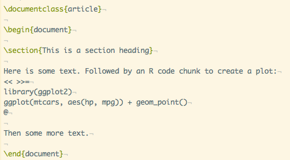

Note that in a knitr-\(\LaTeX\) document (also known as R Sweave and has the file extension *.Rnw*) code chunks are delimited with `<< >>=` and `@`.

## PDF Output

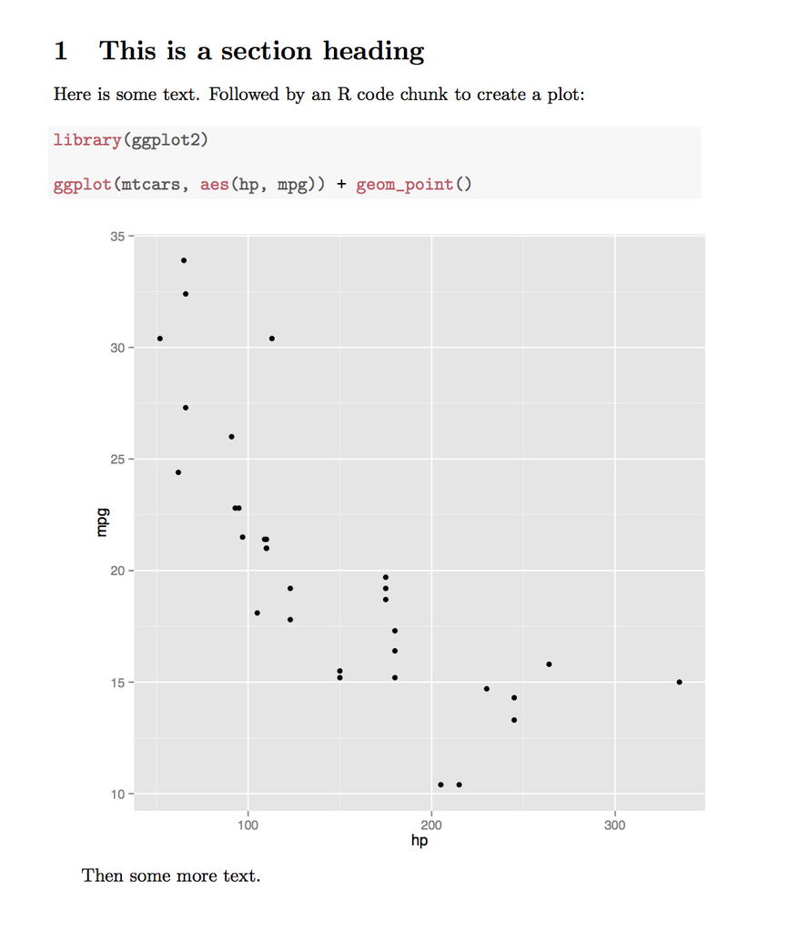

## The knitr process

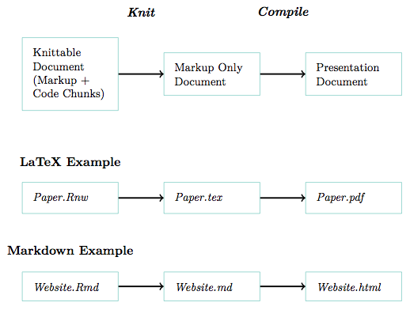

## More recently

Most of the focus is on [RStudio's R Markdown](http://rmarkdown.rstudio.com/).

- Directly builds on knitr (Yihui works at RStudio now).
  - Code chunk syntax is almost identical to Markdown in knitr.
- But uses [Pandoc](http://johnmacfarlane.net/pandoc/) to be more **output agnostic**.
  - You can write in (easy) R Markdown and output to **many different formats**.

## Markdown

Originally created by John Gruber to be an easy way to:

- write HTML files
- that are **human readable as text files**.

## Markdown: HTML less painful

**HTML**:

```
<h1>A header</h1>

<p>This is some text with a <a href="http://www.example.com">link</a></p>

<p>Here is some <strong>bold</strong> text.</p>
```

**Markdown**:

```
# A header

This is some text with a [link](http://www.example.com).

Here is some **bold** text.
```

## Markdown syntax: Headers

```
# Header 1

## Header 2

### Header 3
```

And so on.

## Markdown syntax

Horizontal lines:

```
---
```

Bold text:

```
**bold**
```

Italics:

```
*italics*
```

## Markdown syntax

Links:

```
[link](http://www.example.com)
```

Images:

```
![text description](FILE/PATH.png)
```

## Markdown syntax

Unordered Lists:

```
- An item

- An item

- An item
```

Ordered Lists:

```
1. Item one

2. Item two

3. Item three
```

## Tables

```
| Name   | Something |
| ------ | --------- |
| Stuff  | Things    |
| Things | Stuff     |
```

| Name | Something |
| --- | --- |
| Stuff | Things |
| Things | Stuff |

## Math

R Markdown from RStudio supports [MathJax](http://www.mathjax.org/). So, you can write any [\(\LaTeX\) math](http://en.wikibooks.org/wiki/LaTeX/Mathematics) with R Markdown.

```
Inline equations have one dollar sign $s^2 =
\frac{\sum(x - \bar{x})^2}{n - 1}$.
```

**Inline equations** have one dollar sign \(s^2 = \frac{\sum(x - \bar{x})^2}{n - 1}\).

**Display equations** have two dollar signs:

```
$$s^2 = \frac{\sum(x - \bar{x})^2}{n - 1}$$
```

\[s^2 = \frac{\sum(x - \bar{x})^2}{n - 1}\]

## Expansion

You can include **any** HTML syntax in a Markdown document. You can also change the formatting by adding a **custom CSS** file (just like a website).

However, this will **only render in HTML output.**

If you are using \(\LaTeX\) (other than math syntax), you can also include \(\LaTeX\) syntax in your RMarkdown document for rendering as a PDF.

## Code chunks Inline

Knitable inline chunks with a back-tick then `r`.

For example:

```r
Two plus two equals `r 2 + 2`.
```

Produces:

Two plus two equals 4.

## Code chunks in Display

Use three ticks (```) to **start** and **end** a code chunk that is **not run**.

Create a **knit-able** code chunk begin the chunk with ````{r}`.

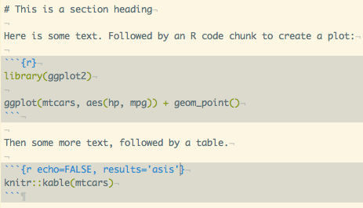

## Automatic table generation (basics)

You can turn any matrix or data frame into a well formatted table with the knitr function `kable`.

```r
knitr::kable(mtcars)
```

Make sure that the code chunk option `results='asis'`.

## Output Web

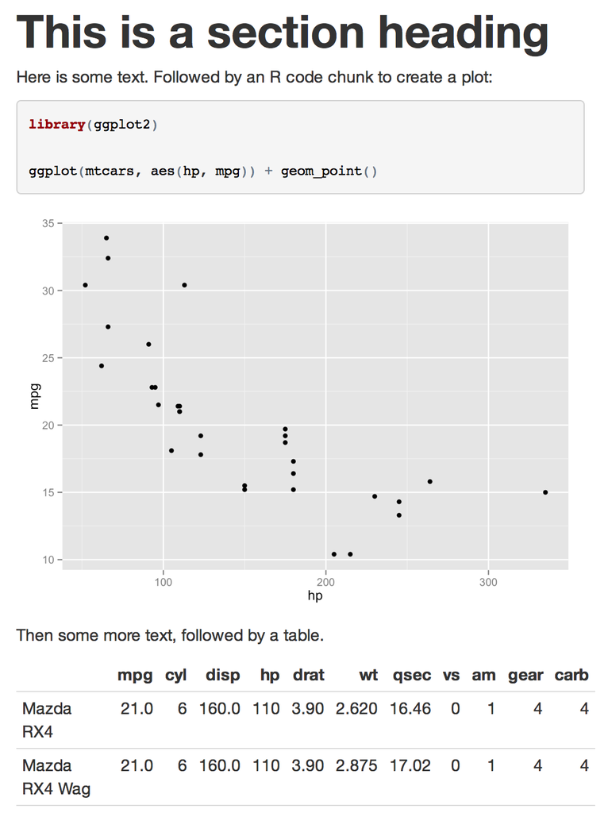

## Output PDF or Word

This R Markdown file can be compiled to PDF (via \(\LaTeX\)) or MS Word with RStudio.

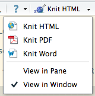

choose output

## Output PDF

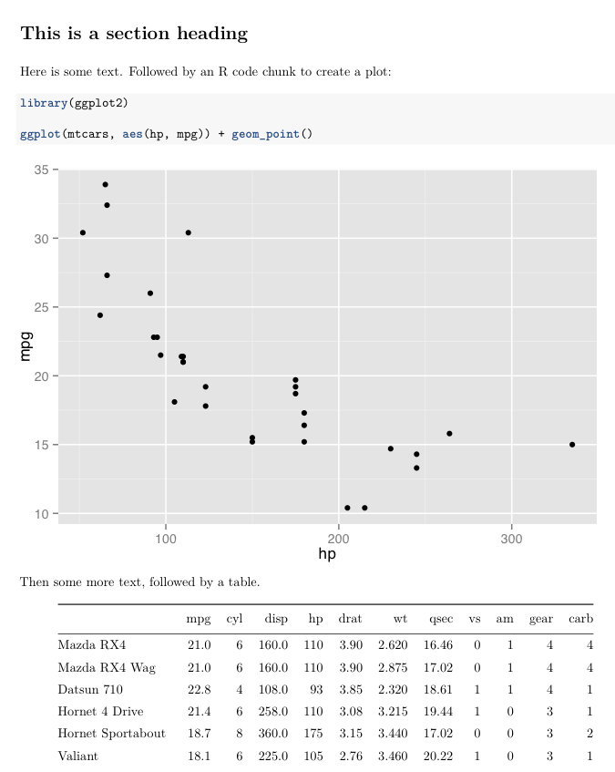

## Output Word

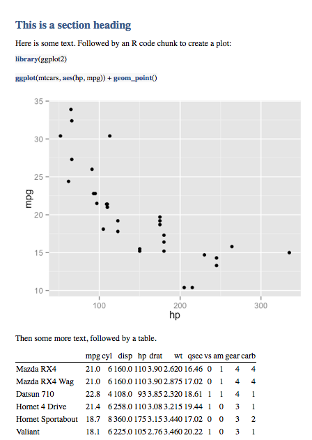

## Chunk options

Change how R Markdown chunks behave with **options**. Place options in the chunk head: ````{r echo=FALSE, error=FALSE}`

| Option | What it Does |
| --- | --- |
| `echo=FALSE` | Does not print the code only the output |
| `error=FALSE` | Does not print errors |
| `include=FALSE` | Does not include the code or output, but does run the code |
| `fig.width` | Sets figure width |
| `cache=TRUE` | Cache the chunk. It is only run when the contents change. |

Many others at http://yihui.name/knitr/options

## RMarkdown Presentations

These lecture slides are created using R Markdown.

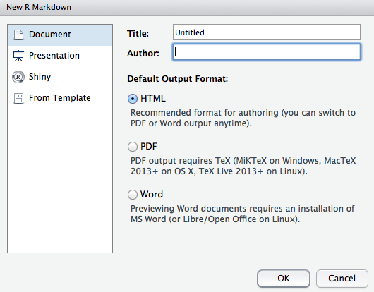

presentation select

## RMarkdown Presentations

All of the syntax is the same, **except**:

`##` Does not mean Header 2. It is creates a **new slide and title**.

You can create a slide with no title using `---`.

## R Markdown Header

The header lets you make changes to the whole document.

This presentation's head is:

```
---
title: 'MPP-E1180 Lecture 4: Intro to Markup Lang. & Literate Programming (1)'
author: "Christopher Gandrud"
date: "22 February 2016"
output:
  ioslides_presentation:
    css: https://maxcdn.bootstrapcdn.com/font-awesome/4.4.0/css/font-awesome.min.css
    logo: https://raw.githubusercontent.com/christophergandrud/Hertie_Collab_Data_Science/master/img/HertieCollaborativeDataLogo_v1.png
  beamer_presentation: default
---
```

We'll look at headers more next lecture

## More reference

For a really good RMarkdown cheatsheet see: https://www.rstudio.com/wp-content/uploads/2015/03/rmarkdown-reference.pdf.

## Seminar: Create R Markdown Documents

Convert what work you have done on your Pair Assignment 1 to R Markdown and output to multiple formats.

- Add relevant equations.

Create a basic R Markdown presentation.

## Seminar: Collaborative Research Project

Begin trying to find a partner for the Collaborative Research Project.

Discuss topics you might be interested in researching.